# Grammar of Graphics and ggplot2

In this multi-part lecture we will be working through an example of building out a nice visualization. We will be learning one of the most common and popular libraries for data visualization in R, **ggplot2**. This lecture will just give a brief introduction to the library and some options for plotting. Eventually we will choose a particular method for static plots and then have separate lectures for each plot type!

Now for a quick overview of ggplot2!

ggplot2 has several advantages:

- Plot specification at a high level of abstraction
- Very flexible
- Theme system for polishing plot appearance
- Mature and complete graphics system
- Many users, active mailing list
- Lot's of online help available (StackOverflow, etc...)

What ggplot2 not ideal for:

- Interactive graphics
- Graph Theory Plots (Graph Nodes)
- 3-D Graphics

Later on we'll learn about other libraries better suited for those topics. As we go through this tutorial on ggplot2, it may be helpful to use this [useful cheat sheet](https://www.rstudio.com/wp-content/uploads/2015/03/ggplot2-cheatsheet.pdf) for reference when using ggplot2!

# Grammar of Graphics

ggplot2 is based on the grammar of graphics, the idea that you can build every graph from the same few components: a data set, a set of geoms—visual marks that represent data points, and a coordinate system. To display data values, map variables in the data set to aesthetic properties of the geom like size, color, and x and y locations.

## Layers for building Visualizations

ggplot2 is based off the grammar of graphics, which sets a paradigm for data visualization in layers:

[figure not shown]

We won't go too much in depth to the over all philosophy of the grammar of graphics because the best source of this is from the creator of ggplot, Hadley Wickham, who created a great paper on the topic which you can read [here](http://vita.had.co.nz/papers/layered-grammar.pdf).

As far as the syntax for grammar of graphics and ggplot, we can get a better understanding through some quick examples. In this lecture we'll quickly show some syntax examples, then in the following lectures we'll show various examples of specific plot types using qplot() and ggplot(), then we'll wrap our understanding by building off the final layers of the grammar of graphics and then having an assignment for recreating a plot.

## Data and Set-up

Let's get started:

```r
# import ggplot2
library(ggplot2)
```

The general syntax of using ggplot2 will look like this:

```
ggplot(data = <default data set>,
       aes(x = <default x axis variable>,
           y = <default y axis variable>,
           ... <other default aesthetic mappings>),
       ... <other plot defaults>) +

       geom_<geom type>(aes(size = <size variable for this geom>,
                      ... <other aesthetic mappings>),
                  data = <data for this point geom>,
                  stat = <statistic string or function>,
                  position = <position string or function>,
                  color = <"fixed color specification">,
                  <other arguments, possibly passed to the _stat_ function) +

  scale_<aesthetic>_<type>(name = <"scale label">,
                     breaks = <where to put tick marks>,
                     labels = <labels for tick marks>,
                     ... <other options for the scale>) +

  theme(plot.background = element_rect(fill = "gray"),
        ... <other theme elements>)
```

We'll build up an understanding of this piece by piece. But first we'll need data! We'll use some real estate data available in this repo or you can download it [here](https://www.dropbox.com/s/qsa7iub5ead8slt/state_real_estate_data.csv?dl=0)

```r
library(data.table)
# You may need to put the entire file path to the downloaded csv file!
df <- fread('state_real_estate_data.csv')
```

```r
head(df)
```

|  | State | region | Date | Home.Value | Structure.Cost | Land.Value | Land.Share..Pct. | Home.Price.Index | Land.Price.Index |
| --- | --- | --- | --- | --- | --- | --- | --- | --- | --- |
| 1 | AK | West | 20101 | 224952 | 160599 | 64352 | 28.6 | 1.481 | 1.552 |
| 2 | AK | West | 20102 | 225511 | 160252 | 65259 | 28.9 | 1.484 | 1.576 |
| 3 | AK | West | 20093 | 225820 | 163791 | 62029 | 27.5 | 1.486 | 1.494 |
| 4 | AK | West | 20094 | 224994 | 161787 | 63207 | 28.1 | 1.481 | 1.524 |
| 5 | AK | West | 20074 | 234590 | 155400 | 79190 | 33.8 | 1.544 | 1.885 |
| 6 | AK | West | 20081 | 233714 | 157458 | 76256 | 32.6 | 1.538 | 1.817 |

```r
tail(df)
```

|  | State | region | Date | Home.Value | Structure.Cost | Land.Value | Land.Share..Pct. | Home.Price.Index | Land.Price.Index |
| --- | --- | --- | --- | --- | --- | --- | --- | --- | --- |
| 1 | DC | NA | 20092 | 630361 | 148268 | 482092 | 76.5 | 2.409 | 2.802 |
| 2 | DC | NA | 20093 | 632103 | 148074 | 484029 | 76.6 | 2.415 | 2.817 |
| 3 | DC | NA | 20114 | 676463 | 165456 | 511007 | 75.5 | 2.585 | 3.025 |
| 4 | DC | NA | 20121 | 690234 | 166701 | 523532 | 75.8 | 2.637 | 3.107 |
| 5 | DC | NA | 20122 | 705645 | 167978 | 537666 | 76.2 | 2.696 | 3.198 |
| 6 | DC | NA | 20123 | 722514 | 169289 | 553225 | 76.6 | 2.761 | 3.299 |

```r
str(df)
```

```
Classes ‘data.table’ and 'data.frame':	7803 obs. of  9 variables:
 $ State           : chr  "AK" "AK" "AK" "AK" ...
 $ region          : chr  "West" "West" "West" "West" ...
 $ Date            : int  20101 20102 20093 20094 20074 20081 20082 20083 20084 20091 ...
 $ Home.Value      : int  224952 225511 225820 224994 234590 233714 232999 232164 231039 229395 ...
 $ Structure.Cost  : int  160599 160252 163791 161787 155400 157458 160092 162704 164739 165424 ...
 $ Land.Value      : int  64352 65259 62029 63207 79190 76256 72906 69460 66299 63971 ...
 $ Land.Share..Pct.: num  28.6 28.9 27.5 28.1 33.8 32.6 31.3 29.9 28.7 27.9 ...
 $ Home.Price.Index: num  1.48 1.48 1.49 1.48 1.54 ...
 $ Land.Price.Index: num  1.55 1.58 1.49 1.52 1.89 ...
 - attr(*, ".internal.selfref")=<externalptr>
```

```r
summary(df)
```

```
    State              region               Date         Home.Value
 Length:7803        Length:7803        Min.   :19751   Min.   : 18763
 Class :character   Class :character   1st Qu.:19843   1st Qu.: 62235
 Mode  :character   Mode  :character   Median :19941   Median :108724
                                       Mean   :19939   Mean   :135313
                                       3rd Qu.:20033   3rd Qu.:172030
                                       Max.   :20131   Max.   :862885
 Structure.Cost     Land.Value     Land.Share..Pct. Home.Price.Index
 Min.   : 17825   Min.   :   938   Min.   : 5.00    Min.   :0.1350
 1st Qu.: 53776   1st Qu.:  4178   1st Qu.: 5.00    1st Qu.:0.4550
 Median : 88352   Median :  9478   Median :10.40    Median :0.7830
 Mean   : 99534   Mean   : 35779   Mean   :18.17    Mean   :0.8695
 3rd Qu.:134871   3rd Qu.: 38631   3rd Qu.:26.30    3rd Qu.:1.2075
 Max.   :325595   Max.   :594417   Max.   :81.70    Max.   :2.8930
 Land.Price.Index
 Min.   : 0.0000
 1st Qu.: 0.0020
 Median : 0.2520
 Mean   : 0.9912
 3rd Qu.: 1.1510
 Max.   :15.4340
```

# Using ggplot2

## Quick Example with Histograms

Histograms are a great way of quickly exploring your data! We have a couple of options for quickly producing histograms off the columns of a data frame. We have:

- hist()
- qplot()
- ggplot()

They differ mainly in one main component, for each of these methods you usually trade-off ease of use for ability to customize.

**Note! In RStudio you'll need to call print(plot_name) to display your plots. Also the plots will look a lot better in RStudio than here in the notes.**

Let's show quick use cases of each:

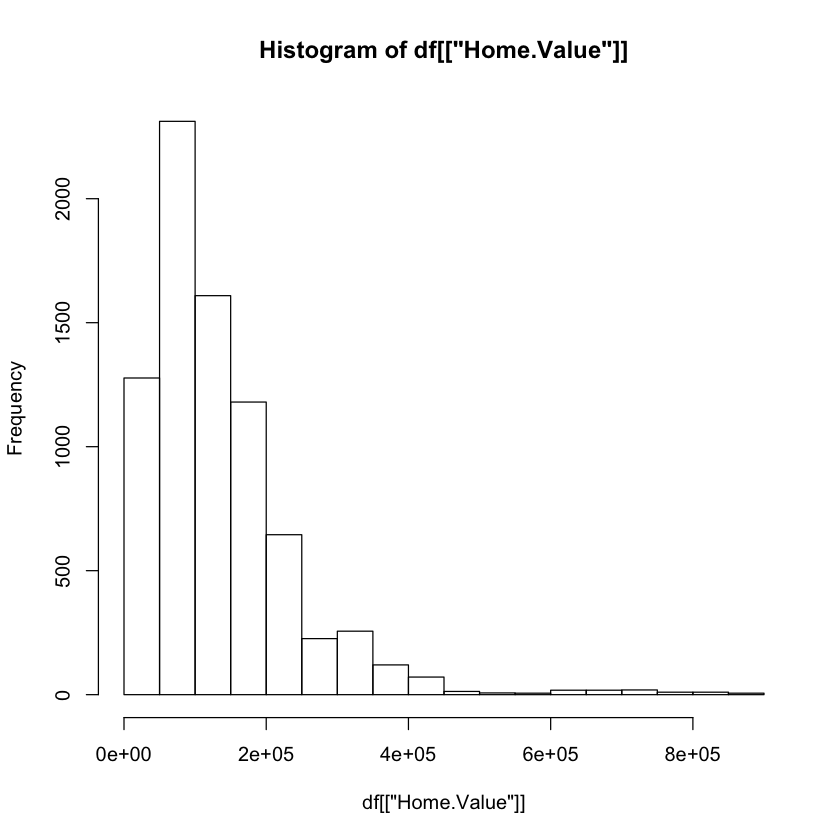

```r
# Pass a column straight into hist()
hist(df[['Home.Value']])
```

**Using qplot**

Notice the auto-adjustment of the color theme and the binwidth.

```
stat_bin: binwidth defaulted to range/30. Use 'binwidth = x' to adjust this.
```

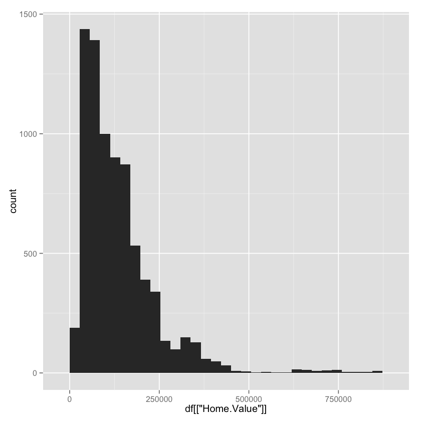

```r
qplot(df[['Home.Value']])
```

```
stat_bin: binwidth defaulted to range/30. Use 'binwidth = x' to adjust this.
```

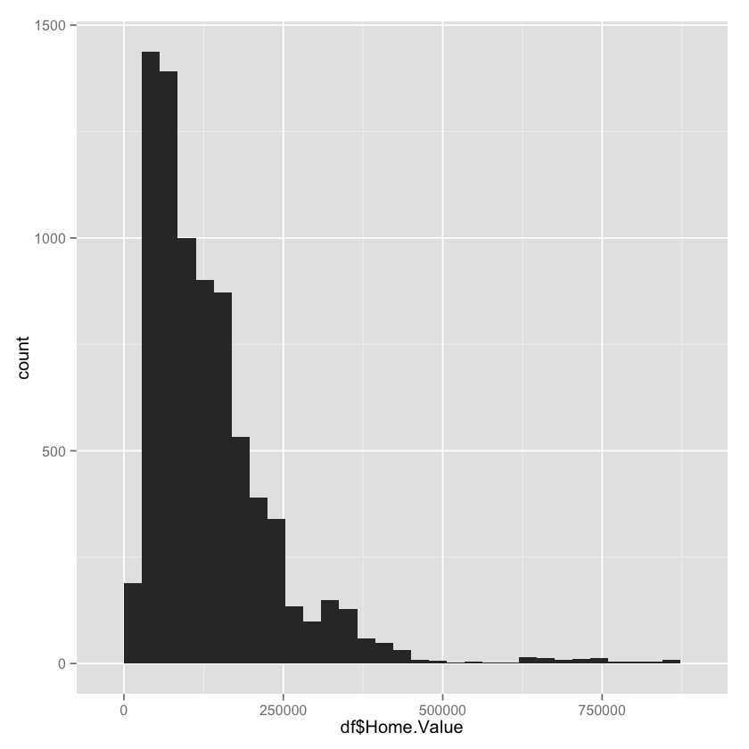

```r
# Using ggplot, lots of ability to customize, but bit more complicated!
ggplot(data = df,aes(df$Home.Value))+geom_histogram()
```

So what method should we choose? Usually the **qplot()** function will give us a nice balance between ease of use and ability to customize, let's quickly break down the syntax for using **qplot()**.

## qplot

The qplot() function can be used to create the most common graph types. While it does not expose ggplot's full power, it can create a very wide range of useful plots. The format is:

```
qplot(x, y, data=, color=, shape=, size=, alpha=, geom=, method=, formula=, facets=, xlim=, ylim= xlab=, ylab=, main=, sub=)
```

Each of these additional arguments provide methods for customizing your plot further:

| **option** | **description** |
| --- | --- |
| alpha | Alpha transparency for overlapping elements expressed as a fraction between 0 (complete transparency) and 1 (complete opacity) |
| color, shape, size, fill | Associates the levels of variable with symbol color, shape, or size. For line plots, color associates levels of a variable with line color. For density and box plots, fill associates fill colors with … |
| data | Specifies a data frame |
| facets | Creates a trellis graph by specifying conditioning variables. Its value is expressed as *rowvar* ~ *colvar*. To create trellis graphs based on a single conditioning variable, use *rowvar*~. or .~*colv… |
| geom | Specifies the geometric objects that define the graph type. The geom option is expressed as a character vector with one or more entries. geom values include "point", "smooth", "boxplot", "line", "hist… |
| main, sub | Character vectors specifying the title and subtitle |
| method, formula | If geom="smooth", a loess fit line and confidence limits are added by default. When the number of observations is greater than 1,000, a more efficient smoothing algorithm is employed. Methods include … |
| *x*, *y* | Specifies the variables placed on the horizontal and vertical axis. For univariate plots (for example, histograms), omit *y* |
| xlab, ylab | Character vectors specifying horizontal and vertical axis labels |
| xlim,ylim | Two-element numeric vectors giving the minimum and maximum values for the horizontal and vertical axes, respectively |

## Quick Example of Customization

Let's explore qplot further! In the last example we just passed a single column and qplot automatically knew to do a histogram, from now on we're going to be a little more formal and pass in the entire data source and then specify what columns to grab and how to plot it:

```
stat_bin: binwidth defaulted to range/30. Use 'binwidth = x' to adjust this.
```

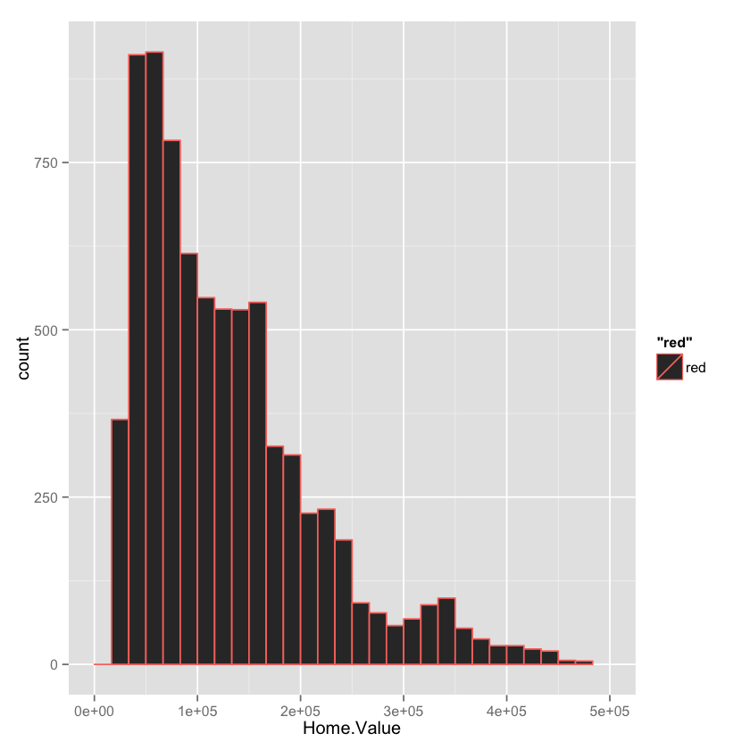

```r
# Customize the histogram further
qplot(data=df,x=Home.Value,geom = 'histogram',xlim=c(0,500000), color='red')
```

## Conclusion

Great! Hopefully you've begin to see how powerful ggplot2. From now on we will explore each plot type indvidually and show how to construct it in **qplot** and then show how to create it with **ggplot()**. This ggplot knowledge will be especially useful when we begin to create interactive visualizations with plotly's library.